# Week 9 / Exploratory Data Analysis, base graphics, Lab 06

AG Schissler

Wednesday October 23, 2019

## I. Opening

### I. Start-of-class work

1. Log in the your workstation.
2. Open the RStudio application on your machine.
3. Open 17_base_graphics_continueLab06.Rmd from website so that you can work along the lecture.
4. Open lab_06_base_graphics.Rmd to have the lab available.

### This week’s agenda

- Continue *Working with data* Unit II.
- Focus on using R to plot data to conduct exploratory data analysis (EDA).

### Today learning outcomes

Students will be able to

- use base R graphics to plot data

## II. Curves, surfaces, and colors

### Drawing a curve

To draw a curve of a function, use `curve()`

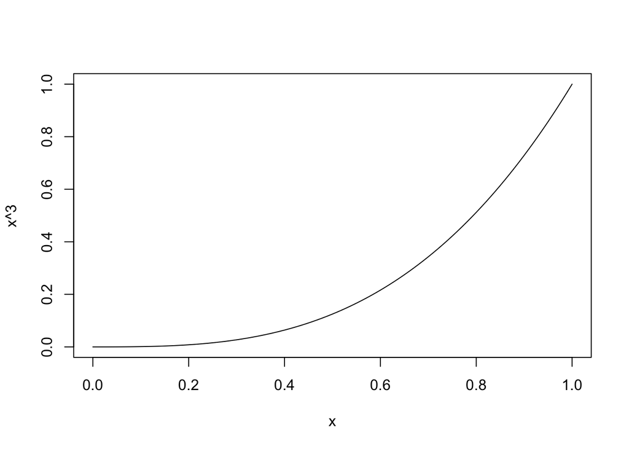

```r
curve(x^3) # Default is to plot between 0 and 1. Note: x here is a symbol
```

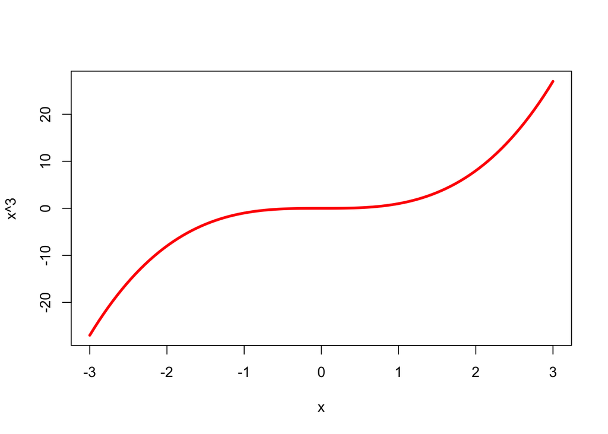

```r
curve(x^3, from=-3, to=3, lwd=3, col="red") # More plotting options
```

### Adding a curve to an existing plot

To add a curve to an existing plot, use `curve()` with `add=TRUE`

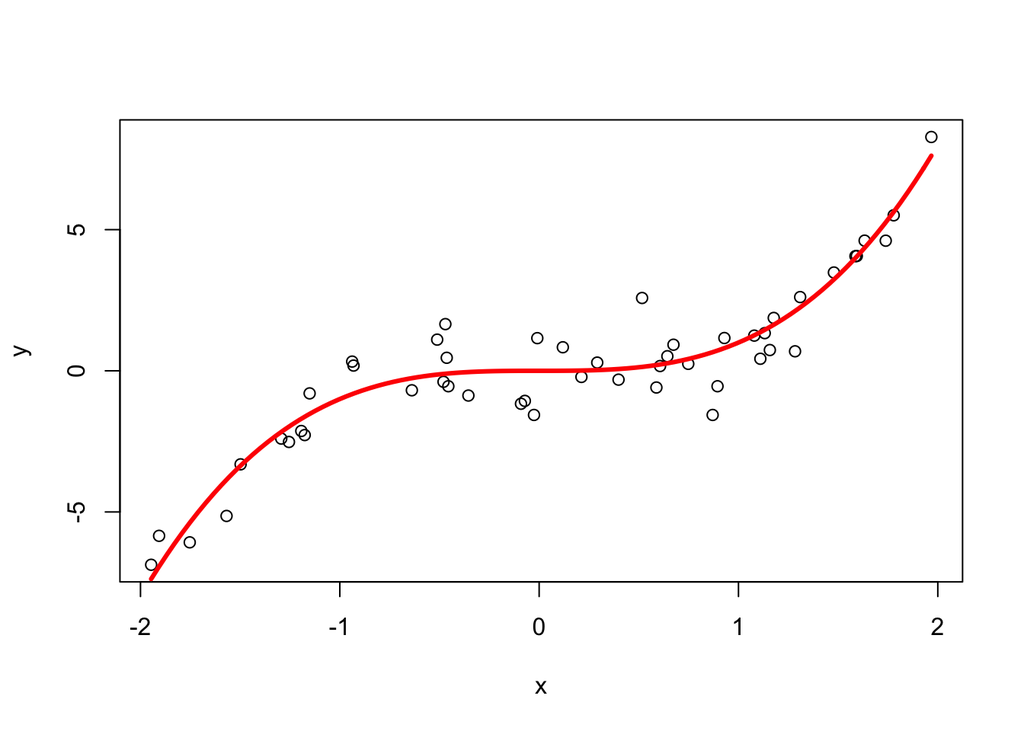

```r
n = 50
set.seed(0)
x = sort(runif(n, min=-2, max=2))
y = x^3 + rnorm(n)

plot(x, y)
curve(x^3, lwd=3, col="red", add=TRUE)
```

```r
# Note: the x argument here and the x vector we defined above are different!
# Reminder: x here is a symbol
```

### Adding a rug to an existing plot

To add a rug to an existing plot (just tick marks, for where the x points occur), use `rug()`

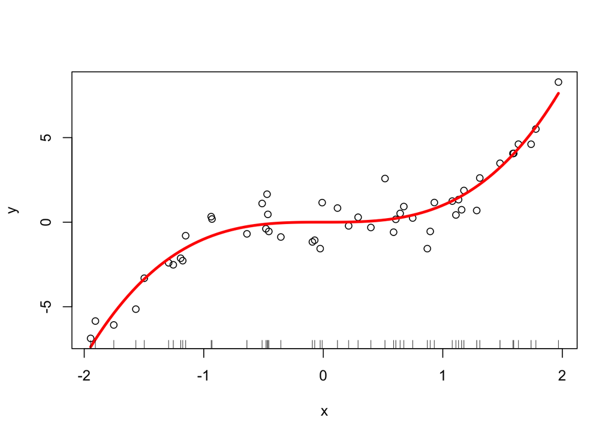

```r
plot(x, y)
curve(x^3, lwd=3, col="red", add=TRUE)
rug(x)
```

### Drawing a surface

To draw a surface, use the custom function `surface()` given below. This function wraps around the built-in `persp()` function.

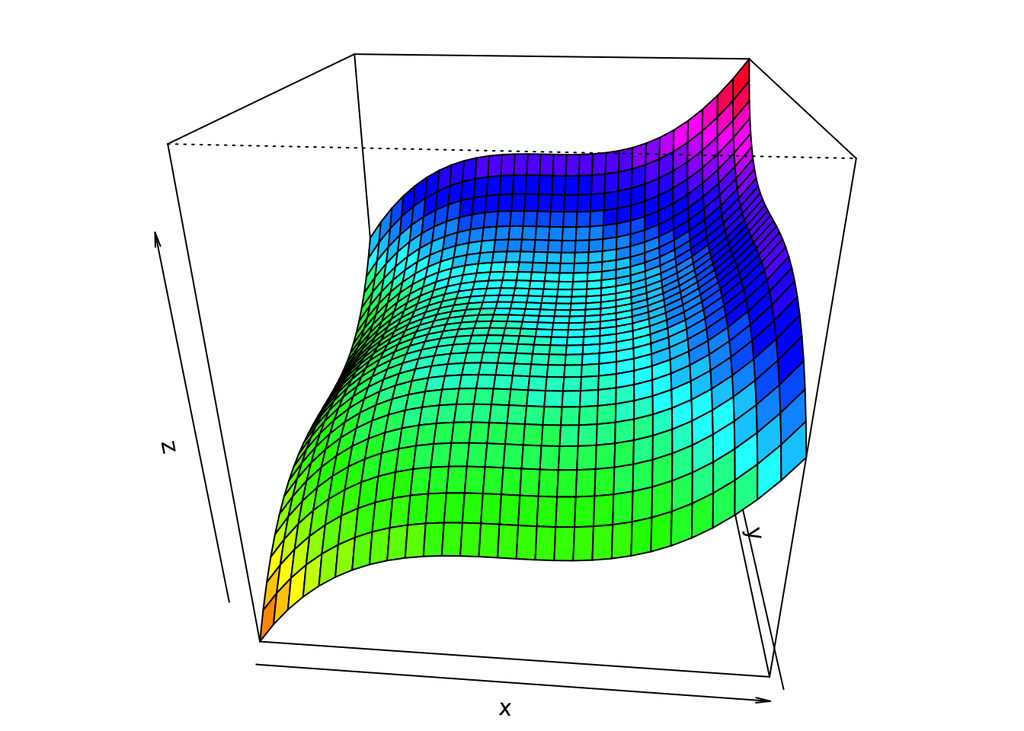

```r
surface = function(expr, from.x=0, to.x=1, from.y=0, to.y=1, n.x=30,
  n.y=30, col.list=rainbow(30), theta=5, phi=25, mar=c(1,1,1,1), ...) {
  # Build the 2d grid
  x = seq(from=from.x,to=to.x,length.out=n.x)
  y = seq(from=from.y,to=to.y,length.out=n.y)
  plot.grid = expand.grid(x=x,y=y)

  # Evaluate the expression to get matrix of z values
  uneval.expr = substitute(expr)
  z.vals = eval(uneval.expr,envir=plot.grid)
  z = matrix(z.vals,nrow=n.x)

  # Figure out margins
  orig.mar = par()$mar # Save the original margins
  par(mar=mar)
  col.grid = col.list[round((z[-1,-1]-min(z))/(max(z)-min(z))
    * (length(col.list)-1) + 1)]
  r = persp(x,y,z,theta=theta,phi=phi,col=col.grid,...)
  par(mar=orig.mar) # Restore the original margins
  invisible(r) # Return the persp object invisibly
}
surface(x^3 + y^3, from.x=-3, to.x=3, from.y=-3, to.y=3)
```

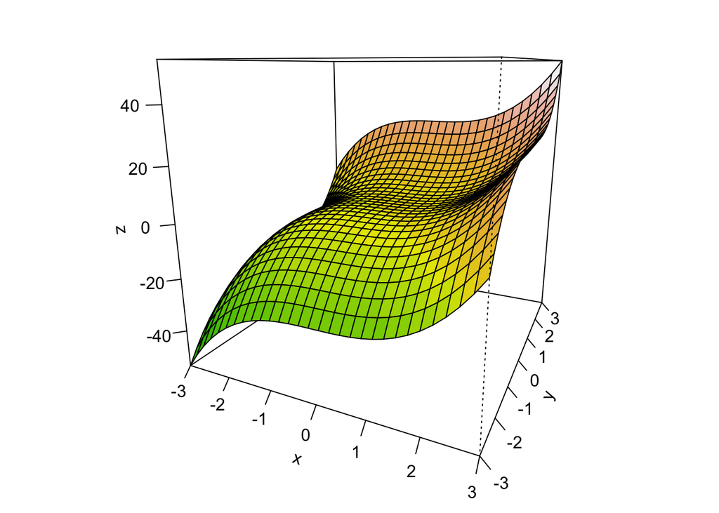

```r
surface(x^3 + y^3, from.x=-3, to.x=3, from.y=-3, to.y=3,
        theta=25, phi=15, col=terrain.colors(30),
        ticktype="detailed", mar=c(2,2,2,2))
```

# Adding points to a surface

To add points to a surface, save the output of `surface()`. Then use `trans3d()`, to transform (x,y,z) coordinates to (x,y) coordinates that you can pass to `points()`

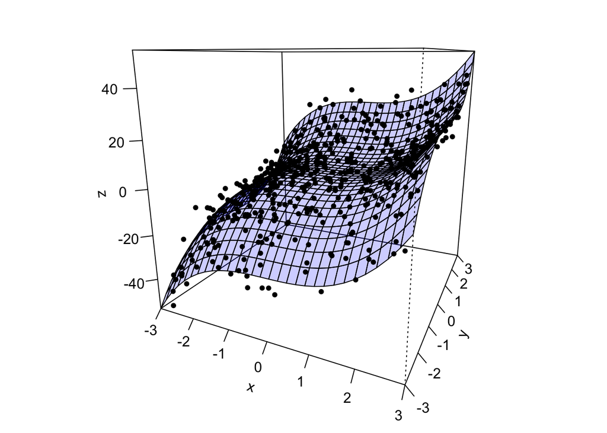

```r
persp.mat = surface(x^3 + y^3, from.x=-3, to.x=3, from.y=-3, to.y=3,
                    theta=25, phi=15, col=rgb(0,0,1,alpha=0.2),
                    ticktype="detailed", mar=c(2,2,2,2))

n = 500
x = runif(n, -3, 3)
y = runif(n, -3, 3)
z = x^3 + y^3 + 5*rnorm(n)

xy.list = trans3d(x, y, z, persp.mat)
points(xy.list, pch=20)
```

### Color palettes

Color palettes are functions for creating vectors of contiguous colors, just like `gray.colors()`, `rainbow()`, `heat.colors()`, `terrain.colors()`, `topo.colors()`, `cm.colors()`. Given a number n, each of these functions just returns a vector of colors (names, stored as strings) of length n

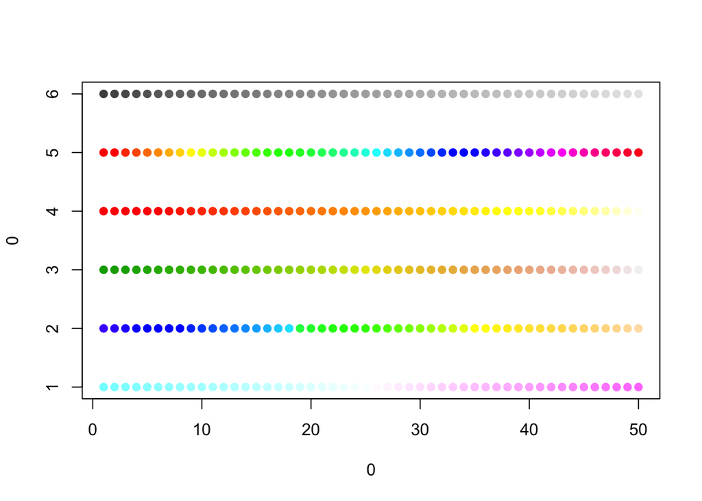

```r
n = 50
plot(0, 0, type="n", xlim=c(1,n), ylim=c(1,6))
points(1:n, rep(6,n), col=gray.colors(n), pch=19)
points(1:n, rep(5,n), col=rainbow(n), pch=19)
points(1:n, rep(4,n), col=heat.colors(n), pch=19)
points(1:n, rep(3,n), col=terrain.colors(n), pch=19)
points(1:n, rep(2,n), col=topo.colors(n), pch=19)
points(1:n, rep(1,n), col=cm.colors(n), pch=19)
```

### Creating a custom color palette

To create a custom palette, that interpolates between a set of base colors, `colorRampPalette()`

```r
cust.colors = colorRampPalette(c("red","purple","darkgreen"))
class(cust.colors)
```

```
## [1] "function"
```

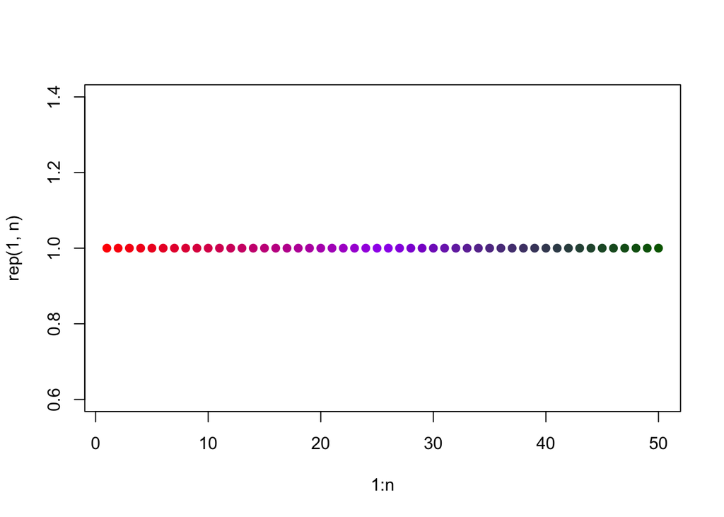

```r
plot(1:n, rep(1,n), col=cust.colors(n), pch=19)
```

### Coloring points by value

Coloring points according to the value of some variable can just be done with a bit of indexing, and the tools you already know about colors

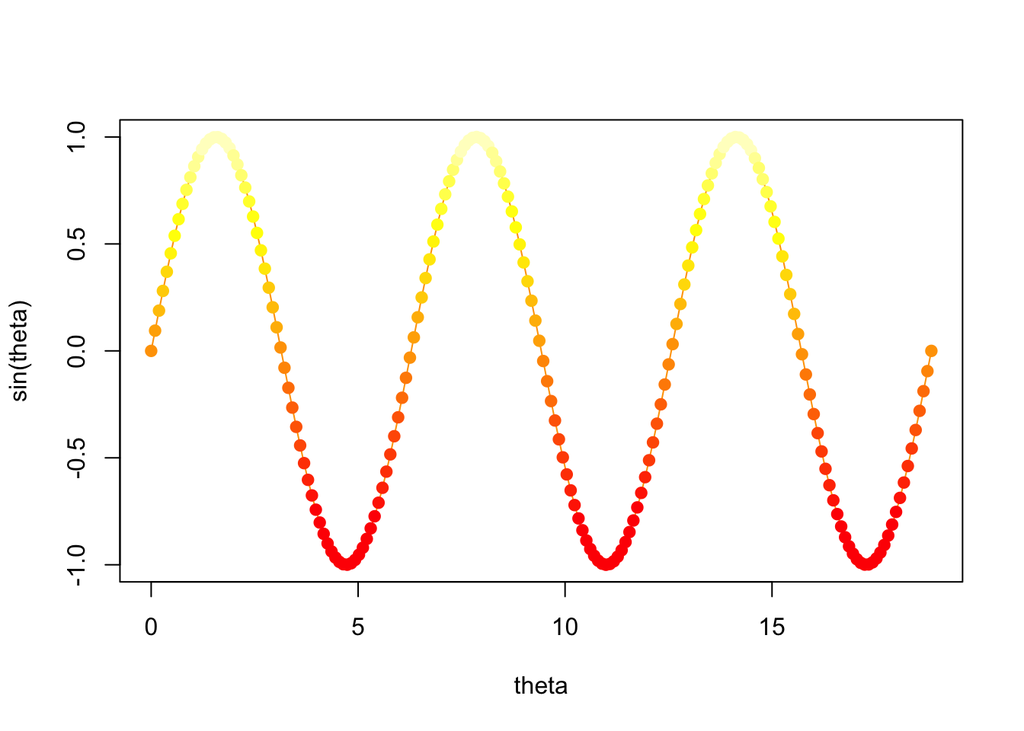

```r
# Function to retrieve a color according to a value
# - val: the value in question
# - lim: a vector of length 2, lower and upper limits for possible values
# - col.vec: the color vector to choose from
get.col.from.val = function(val, lim, col.vec) {
  col.vec[(val-lim[1])/(lim[2]-lim[1]) * (length(col.vec)-1) + 1]
}

# Let's color points according to y value
col.vec = heat.colors(30)
lim = c(-1, 1)
theta = seq(0, 6*pi, length=200)

plot(theta, sin(theta), type="o", pch=19,
     col=get.col.from.val(sin(theta), lim, col.vec))
```

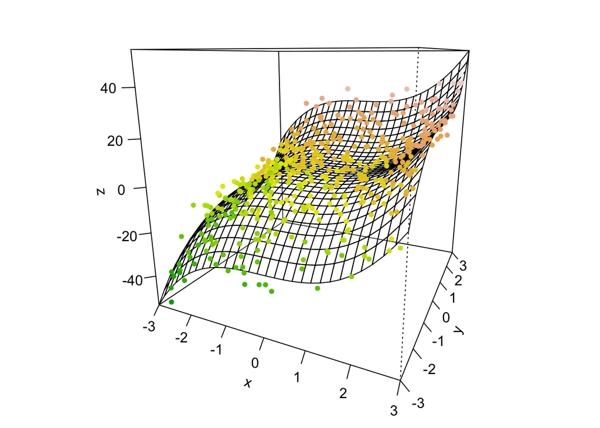

```r
# Another example, now in 3d
persp.mat = surface(x^3 + y^3, from.x=-3, to.x=3, from.y=-3, to.y=3,
                    theta=25, phi=15, col=rgb(1,1,1,alpha=0.2),
                    ticktype="detailed", mar=c(2,2,2,2))

# Let's color points according to z value
col.vec = terrain.colors(30)
lim = c(min(z), max(z))

xy.list = trans3d(x, y, z, persp.mat)
points(xy.list, pch=20, col=get.col.from.val(z, lim, col.vec))
```

### Summary

- `plot()`: generic plotting function
- `points()`: add points to an existing plot
- `lines()`, `abline()`: add lines to an existing plot
- `text()`, `legend()`: add text to an existing plot
- `rect()`, `polygon()`: add shapes to an existing plot
- `hist()`, `image()`: histogram and heatmap
- `heat.colors()`, `topo.colors()`, etc: create a color vector
- `density()`: estimate density, which can be plotted
- `contour()`: draw contours, or add to existing plot
- `curve()`: draw a curve, or add to existing plot

## III. Please continue Lab 06

- Questions for the whole group? Please don’t be shy it could save us all effort.
- Please begin and I will answer questions in the order I receive them and considering who I have helped previously in class.

## IV. Summary

Describe the concept of **layers** in plotting data.